# Analysis of Social media and K-Pop: reasons for its rise and popularity

### Kari Huang, Sooboree Jeung

## INTRODUCTION

As the Internet improves connectivity around the world every day, there seems to be an endless amount of fresh art, film and other media in the world.

Thanks to the Internet, K Pop, an acronym for Korean popular music, was introduced to many countries and cultures around the globe. Anyone who has seen the ‘Gangnam Style' music video might think that they know a bit about K-Pop, but K-Pop is more than just this song.

According to [Vox](https://www.vox.com/culture/2018/2/16/16915672/what-is-kpop-history-explained), South Korean artists have charted the Billboard Hot 100 at least eight times since the Wonder Girls first entered with their hit "Nobody", released in four different languages including English in 2009. Since then, K-pop exports have grown significantly, reaching [$189.7](https://m.pulsenews.co.kr/view.php?sc=30800029&year=2021&no=1107417) million only in music album exports in 2021.

Now that we know what and how influential K-Pop is, the next question would be: who are K-Pop audiences? Analyzing the characteristics of K pop fans, who are responsible for the enormous sales of the billion dollar industry, can help ad companies gain “[deeper understanding of their current and potential customers to improve marketing strategy, customer experience, and brand perception](https://www.brandwatch.com/blog/audience-analysis/)”. Doing so can promote an increase in revenues and net profit for not only the Korean music companies, but also ad companies and social media apps such as Facebook.

In this tutorial, our goal is to guide the readers through the five stages of “Data Science Pipeline”: Data collection, Data management, Exploratory data analysis, Hypothesis testing, and Communication of insights attained. Which in our case will be collecting K-pop survey data gathered from social media, cleaning and tidying survey answers, performing demographic analysis of respondents vs money spent on K-pop, predicting how much money is spent given demographic characteristics, and finally conclude and discuss possible further exploration regarding different ways to explore the K-pop industry.

### Required Tools

The following libraries were used for this tutorial:

1. pandas
2. numpys
3. matplotlib
4. sklearn

```python
import pandas as pd
import numpy as np
import matplotlib.pyplot as plt
import matplotlib.patches as mpatches
from sklearn.discriminant_analysis import LinearDiscriminantAnalysis
from sklearn.model_selection import train_test_split
from sklearn.metrics import classification_report

import warnings
warnings.filterwarnings("ignore")
```

## 1. DATA COLLECTION:

The dataset was obtained from this [link](https://figshare.com/articles/dataset/KPOP_DATA_xlsx/12095901). Survey data was collected from 240 respondents between February 2019 and May 2019. 23 different questions were asked, and the response type for each question differed as well. For example, 5 questions only asked ‘Yes’ or ‘No’, while most of the others were multiple choice, or even multiple choice and [open-ended](https://www.typeform.com/surveys/question-types/) (meaning respondents can give feedback through a text box) type questions.

We converted the downloaded xlsx file to csv to make it easier to read and convert to dataframe. pd.read_csv() was a useful function to convert the csv file to dataframe. When reading through the data entries of the table, we noticed some repeated non-ascii characters such as '’'. The character was found in place of where an apostrophe should be so we replaced it by doing str.replace('’','\''). Now that the data table has been somewhat readable, let’s move on to the next step: data cleaning.

```python
# read excel spreadsheet
df = pd.read_csv("data.csv", sep=',')

# replace non ascii characters
for col in df:
    df[col] = df[col].str.replace('â€™','\'')
```

## 2. DATA CLEANING

Because of how the survey was designed, it took some time to figure out how to tidy and clean the data when graphing different plots when performing exploratory data analysis and hypothesis testing. Although none of the responses were missing, we had to figure out whether to include or exclude some survey answers. And even though we decide to drop the response, that doesn’t mean we could disregard the entire data entry, or row in this case, of the table because the same table row may have appropriate responses for other types of questions, or columns in this case.

So we decided to split the dataframe into multiple dataframes for exploratory analysis so that we could drop rows based on the plots and analyzawe've created and made in the third part of this tutorial without affecting other possible analyses we could perform on.

- On an average, in one year, how much do you spend on K-Pop merchandise?
- How old are you?
- What is your gender?
- When did you start listening to K-Pop?
- If you do watch K-Pop music videos, how long do you spend watching them?
- What do you do to keep up with K-Pop news?
- Do you attend K-Pop concerts?
- What is your profession?
- Would you say that you are obsessed with K-Pop?
- How many hours do you spend listening to K-Pop?

We then renamed the remaining columns for readability.

In our data exploratory analysis stage, we will examine the relationship between the responses of these columns as we plot different types of graphs. Before splitting the dataframes, we renamed the columns to make it easier to read.

```python
positive_effects = 'Have you experienced any positive effects after consuming K-Pop? '
# dropping irrelevant columns
df.drop(['Timestamp','Has consuming K-Pop affected your personal life in the following ways?','What is the craziest thing you have done in your pursuit and love for K-Pop?','Has K-Pop led you to pursue any of the following?','Has consuming K-Pop taken away most of your time?','Has consuming K-Pop taken away most of your time?', 'Which country are you from?','Why do you like K-Pop?', 'Do you watch K-Pop Youtube videos?', 'Do you listen to K-Pop male groups more than girl group songs?'], inplace=True, axis=1)
df.drop(['If you do spend money on K-Pop merchandise, where do you get money from?', positive_effects, 'Which is your favourite K-Pop group?'], inplace= True, axis=1)
# rename columns
df.rename(columns={'On an average, in one year, how much do you spend on K-Pop merchandise?':'MONEY_SPENT',
                   'How old are you?':'AGE',
                   'What is your gender?':'GENDER',
                   'When did you start listening to K-Pop?':'YEARS_LISTENED',
                   'How many hours do you spend listening to K-Pop?':'HOURS_LISTNED_DAILY',
                   'If you do watch K-Pop music videos, how long do you spend watching them?':'HOURS_WATCHED_DAILY',
                   'What do you do to keep up with K-Pop news?':'K-POP_NEWS',
                   'What is your profession?':'PROFESSION',
                   'Would you say that you are obsessed with K-Pop?':'OBSESSION',
                   'Do you attend K-Pop concerts?':'ATTEND_CONCERT',
                   'Is K-Pop popular in your country? ':'POPULARITY'}, inplace=True)

df['HOURS_WATCHED_DAILY'] = df['HOURS_WATCHED_DAILY'].fillna(0)
# df
```

We then created a new column MONEY_SPENT_INT to convert the cleaned MONEY_SPENT column to integer values. To do so, we took the average of each range of the responses. For example 50 to 100 was replaced with 75, 100 to 200 was replaced with 150 and so on. This was a necessary step for us to plot the graphs to discover the relationship between other responses.

We have performed the same replacing, cleaning, and conversion for other columns such as hours_listened, years_listened, and hours_watched. For the k-pop_news column, we counted the number of types of k-pop news and made a separate new column num_suscribed. After most of the cleaning was done, we dropped unnecessary columns.

```python
#deal with the customized responses regarding the question "How much do you spend on K-Pop merchandise?"
df['MONEY_SPENT'] = df['MONEY_SPENT'].replace(["I don't spend anything on merchandise",
                                               "I don't spend anything on merchandise ",
                                               "I would like to but I don't have money", 0], "0")
df['MONEY_SPENT'] = df['MONEY_SPENT'].replace(["Below 50$",
                                               "Below 30$",
                                               "10?",
                                               "I spend less than $50 cuz I'm broke, but if I had money, I would probably spend $200+"], "less than $50")
df['MONEY_SPENT'] = df['MONEY_SPENT'].replace("50 - 100 $", "\$50 to \$100")
df['MONEY_SPENT'] = df['MONEY_SPENT'].replace("100 - 200$", "\$100 to \$200")
df['MONEY_SPENT'] = df['MONEY_SPENT'].replace(["More than $200",
                                               "I've spent 200-300 dollars, but i chose not to spend much more unless its clothing or a physical concert. Plus i rlly only ult stan 2 groups",
                                               " Never until Monsta X existed and it's about $300 a year "], "\$200 to \$300")
df['MONEY_SPENT'] = df['MONEY_SPENT'].replace("Kpop is an expensive hobby I go to concerts and buy albums so I would say I've spent more than 1k", '$1000 or more')
df['MONEY_SPENT'] = df['MONEY_SPENT'].replace("$2,000", '$2000 or more')
df['MONEY_SPENT'] = df['MONEY_SPENT'].replace("I've spent probably over $5,000 total on kpop merch (including tickets)",'$5000 or more')
df['MONEY_SPENT'] = df['MONEY_SPENT'].replace(["A lot I don't even want to know how much",
                                               "Depends but usually not a lot. ",
                                               "I don't buy everything. I buy things if I feel I will use them ",
                                               "I've only ever bought merchandise from the two concerts I've been too and that's it.",
                                               "A lot I don't even want to know how much",
                                               "Because I'm younger I don't have the money to spend on official kpop mercy but I do buy smaller things to represent the groups.",
                                               "I've bought some albums over the past few years but its just like a xmas / bday thing i do so twice a year i just purchase however many i can",
                                               "What if you don't know, since everything you own that is K-Pop related were all gifts?",
                                               "Depends month to month and what i want to buy"], "Unknown")
# delete unknown values
df = df[df["MONEY_SPENT"].str.contains("Unknown")==False]

# create new column MONEY_SPENT_INT for converting MONEY_SPENT column to integers
df["MONEY_SPENT_INT"] = df["MONEY_SPENT"].copy()
df['MONEY_SPENT_INT'] = df['MONEY_SPENT_INT'].replace(['0'], 0)
df['MONEY_SPENT_INT'] = df['MONEY_SPENT_INT'].replace(['less than $50'], 50)
df['MONEY_SPENT_INT'] = df['MONEY_SPENT_INT'].replace(['\$50 to \$100'], 75)
df['MONEY_SPENT_INT'] = df['MONEY_SPENT_INT'].replace(['\$100 to \$200'], 150)
df['MONEY_SPENT_INT'] = df['MONEY_SPENT_INT'].replace(['\$200 to \$300'], 250)
df['MONEY_SPENT_INT'] = df['MONEY_SPENT_INT'].replace(['$1000 or more'], 1000)
df['MONEY_SPENT_INT'] = df['MONEY_SPENT_INT'].replace(['$2000 or more'], 2000)
df['MONEY_SPENT_INT'] = df['MONEY_SPENT_INT'].replace(['$5000 or more'], 5000)



# find and categorize open-ended answers to '5 or more'
df['HOURS_LISTNED_DAILY'] = df['HOURS_LISTNED_DAILY'].replace(['Almost all day','All day','Most of the time.',
                                                               'Nearly every hour unless im sleeping',
                                                               'The whole day almost','All the time.','Hours on end',
                                                               'Over half of my day (12+ hours)',
                                                               'It\'s mainly the only music I listen to anymore, I listen to music all the time'],
                                                               '5 or more')
to_delete_values_hours_listened = [
'depends if i\'m in the mood for it',
'Everyday', 'Everyday, constantly ',
'Any chance that i get. (I dont really count the hours) ',
'I mix in other songs in other languages too so very Day is different ',
'Idk depends on my mood. But I can liste during multiple hours definitely. ',
'It\'s depend on day. Usually one or two hours, sometimes more, sometimes, when I overeat kpop I need to do break. ',
'Everyday ',
'Eh',
'I don\'t rlly listen to music, music is like food to me. When I crave a song, I listen to it. So probably less than an hour? When Monsta X has comebacks I do stream (but it\'s just playing in the background sometimes my earphones are plugged in so I don\'t actually hear it)... I listen to it for almost the whole day I guess... gotta get those views and wins ',
'Whenever I\'m listening to music, basically',
'Every time but only when I get the chance cause I\'m busy with school .',
'Anytime I listen to music that\'s all I listen to',
'24-Jul',
'Anytime I listen to music that\'s all I listen to'
]

# delete values
df = df[df.HOURS_LISTNED_DAILY.isin(to_delete_values_hours_listened) == False]

# create new column HOURS_LISTEND_DAILY_INT
df["HOURS_LIS_INT"] = df["HOURS_LISTNED_DAILY"].copy(deep=True)
df['HOURS_LIS_INT'] = df['HOURS_LIS_INT'].replace(['2-4 hours'], 3.)
df['HOURS_LIS_INT'] = df['HOURS_LIS_INT'].replace(['5 or more'], 5.)
df['HOURS_LIS_INT'] = df['HOURS_LIS_INT'].replace(['Less than an hour'], 1.)

# gather cells that from YEARS_LISTENED to categorize reponses to 'More than 4 years ago'
years_4_ago_values = [
'7 years',
'7 years ago',
'7 years ago',
'8+ years ago',
'9 years coming April ',
'9 years, since 2010', 'Started in 2006',
'About 6 years ago, I got introduced to 2ne1 which was their song called â€œI am the bestâ€. So sad they disbanded'
]

# replace values for YEARS_LISTENED and delete values that cannot be categorized
df['YEARS_LISTENED'] = df['YEARS_LISTENED'].replace(years_4_ago_values, 'More than 4 years ago')
df.drop(df.index[(df['YEARS_LISTENED'] == 'I\'ve been listening to it all my life basically, my cousins are Asian, and I\'m mexican, so people think I\'m just a koreaboo, when in reality I\'ve only ever listened to korean and Chinese music')], inplace=True, axis=0)

# create new column HOURS_LISTEND_DAILY_INT
df["HOURS_WATCH_INT"] = df["HOURS_WATCHED_DAILY"].copy(deep=True)
df['HOURS_WATCH_INT'] = df['HOURS_WATCH_INT'].replace(['More than four hours'], 4.1)
df['HOURS_WATCH_INT'] = df['HOURS_WATCH_INT'].replace(['3-4 hours'], 3.5)
df['HOURS_WATCH_INT'] = df['HOURS_WATCH_INT'].replace(['2-3 hours'], 2.5)
df['HOURS_WATCH_INT'] = df['HOURS_WATCH_INT'].replace(['1 hour'], 1.0)

# create new column YEARS_LISTENED_IINT
df["YEARS_LISTENED_INT"] = df["YEARS_LISTENED"].copy(deep=True)
df['YEARS_LISTENED_INT'] = df['YEARS_LISTENED_INT'].replace(['1 -2 years ago'], 1.5)
df['YEARS_LISTENED_INT'] = df['YEARS_LISTENED_INT'].replace(['3-4 years ago'], 3.5)
df['YEARS_LISTENED_INT'] = df['YEARS_LISTENED_INT'].replace(['More than 4 years ago'], 4.0)
df['YEARS_LISTENED_INT'] = df['YEARS_LISTENED_INT'].replace(['Less than a year ago'], 1.0)


# separate profession column to two categories: student and non student (who has occupation)
df.loc[df["PROFESSION"].str.contains("student", case=False), 'PROFESSION'] = 'Student'
df.loc[False == df["PROFESSION"].str.contains("student", case=False), 'PROFESSION'] = 'Not Student'

# replace responses that contain 'twitter' to Twitter for K-POP_NEWS column
df['K-POP_NEWS'] = df['K-POP_NEWS'].replace(['twitter','Twitter','I have allkpop tweets notifcations sent to my phone thats it realy'], 'Twitter')

temp = []

# split responses into arrays and initialze NUM_SUSCRIBED column to number of elements of that splited array
for cell in df['K-POP_NEWS']:
  temp.append(len(cell.split(';')))

#create new column for number of social media suscribed to keep up with k pop news
df['NUM_SUSCRIBED'] = temp.copy()

# delete old columns that won't be used
df.drop(['K-POP_NEWS'], inplace=True, axis=1)
df.drop(['HOURS_WATCHED_DAILY'], inplace=True, axis=1)
df.drop(['YEARS_LISTENED'], inplace = True, axis=1)
df.drop(['HOURS_LISTNED_DAILY'], inplace = True, axis=1)
```

# 3. Exploratory Data Analysis

In this step of data pipelining, we play around with the cleaned data by visualizing relationships between multiple variables and columns.

```python
#reorder dataframe by money spent
spent_order = ['0', 'less than $50', '\$50 to \$100', '\$100 to \$200', '\$200 to \$300', '$1000 or more', '$2000 or more', '$5000 or more']
df['MONEY_SPENT']= pd.Categorical(df['MONEY_SPENT'], categories=spent_order)
df = df.sort_values('MONEY_SPENT')

#get each age range money spent value
spent = []
for age, age_group in df.groupby(['AGE']):
    arr = []
    for name, group in age_group.groupby(['MONEY_SPENT']):
        arr.append(len(group))
    spent.append(arr)

age_10_14 = np.array(spent[0])
age_15_20 = np.array(spent[1])
age_21_26 = np.array(spent[2])
age_27_30 = np.array(spent[3])
```

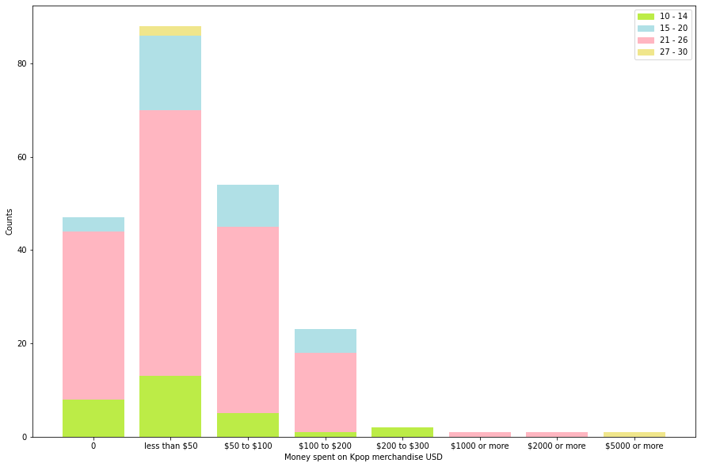

```python
#plot bar in stack manner
plt.figure(figsize=(15,10))
plt.bar(df['MONEY_SPENT'].unique(), age_10_14, color="#BCEC47")
plt.bar(df['MONEY_SPENT'].unique(), age_15_20, bottom=age_10_14, color="lightpink")
plt.bar(df['MONEY_SPENT'].unique(), age_21_26, bottom=age_10_14+age_15_20, color="powderblue")
plt.bar(df['MONEY_SPENT'].unique(), age_27_30, bottom=age_10_14+age_15_20+age_21_26, color="khaki")

plt.xlabel("Money spent on Kpop merchandise USD")
plt.ylabel("Counts")
handles = [mpatches.Patch(color=color, label=label) for label, color in
           [('10 - 14', '#BCEC47'), ('15 - 20', 'powderblue'),('21 - 26', 'lightpink'), ('27 - 30', 'khaki')]]
plt.legend(handles=handles, loc='upper right', frameon=True)
plt.show()
```

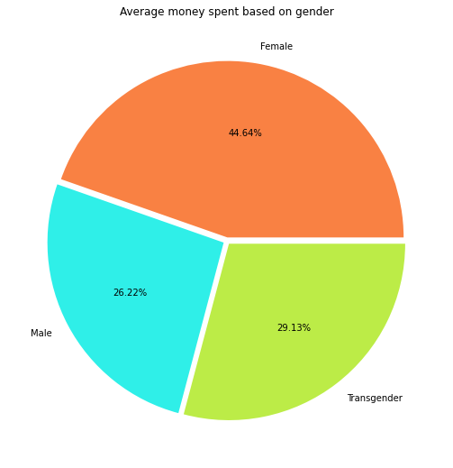

```python
#calculate average money spent based on the gender
gender_df = df[['GENDER', 'MONEY_SPENT_INT']].copy(deep=True)
avg_spent = gender_df.groupby(['GENDER']).apply(lambda x: x.MONEY_SPENT_INT.sum()/len(x))

#create pie chart
gender = ['Female', 'Male', 'Transgender']
chart_explode = [0.02]*3
plt.figure(figsize=(12, 9))
plt.pie(avg_spent, labels=gender, explode=chart_explode, colors=['#F98143', '#2FEFE8', '#BCEC47'], autopct='%1.2f%%')
plt.title("Average money spent based on gender")
plt.show()
```

Our next pie chart compares the average money spent based on gender. It seems that female respondents account most for average money spent, followed by transgenders and males.

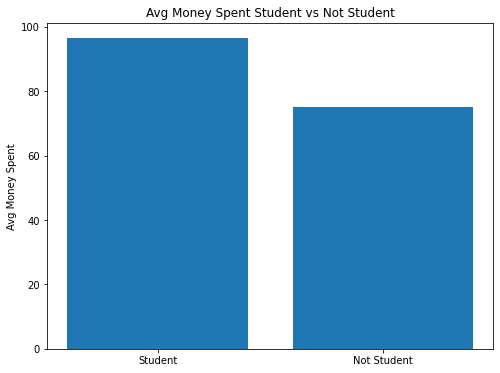

```python
#splitting dataframe ...
job_and_source_df = df[['MONEY_SPENT_INT','PROFESSION']].copy()

# split dataframe into student and not student groups
professions = job_and_source_df.groupby("PROFESSION")

# obtain average money spent for each profession
avg_student = professions.get_group('Student')['MONEY_SPENT_INT'].sum()/len(professions.get_group('Student').index)
avg_nonstudent = professions.get_group('Not Student')['MONEY_SPENT_INT'].sum()/len(professions.get_group('Not Student').index)
# create bar plot comparing average money spent student vs not student using variables avg_student and avg_nonstudent
plt.figure(figsize=(8, 6))
avg_money_spent = [avg_student, avg_nonstudent]
plt.bar(['Student', 'Not Student'], avg_money_spent)
plt.ylabel("Avg Money Spent")
plt.title("Avg Money Spent Student vs Not Student")
plt.show()
```

Next, we compared average money spent based on occupation. We separated the profession types to student vs not student (respondents who had occupation) then grouped the dataframe by profession. For each group, we calculated the sum of money spent and divided it by the number of respondents in each profession group. After plotting we noticed that students spent nearly 100 dollars on average towering non students by 20 dollars.

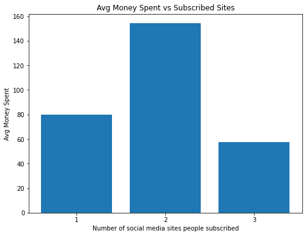

```python
kpop_news_df = df[['NUM_SUSCRIBED', 'MONEY_SPENT_INT']].copy()

# split dataframe into different number of kpop news suscribed
num_kpop_suscribed_groups = kpop_news_df.groupby("NUM_SUSCRIBED")

# create dict to store NUM_SUSCRIBED -> sum of MONEY_SPENT for each group
num_suscribed_dict = {}
for group in num_kpop_suscribed_groups.groups.keys():
  num_suscribed_dict[group] = num_kpop_suscribed_groups.get_group(group)['MONEY_SPENT_INT'].sum()/len(num_kpop_suscribed_groups.get_group(group).index)

# create bar plot comparing average money spent using num_suscribed_dict for each number of k pop new suscribed (3 bars)
plt.figure(figsize=(8, 6))
plt.bar(['1', '2', '3'], num_suscribed_dict.values())
plt.xlabel("Number of social media sites people subscribed")
plt.ylabel("Avg Money Spent")
plt.title("Avg Money Spent vs Subscribed Sites")
plt.show()
```

Our next bar plot compared average money spent based on the number of social media sites people subscribed to. The process to obtain the average was similar to that of the profession bar plot above. Unlike we expected the highest number of social media subscribed to would have the highest average money spent, people who subscribed to two types of k-pop news yielded the most average money spent followed by one and lastly three.

```python
#drop the MONEY_SPENT outlier, which are 1000, 2000, and 5000, since there is only 1 data point for each amount of money spent
df.drop(df.index[(df['MONEY_SPENT_INT'] == 1000)], inplace=True, axis=0)
df.drop(df.index[(df['MONEY_SPENT_INT'] == 2000)], inplace=True, axis=0)
df.drop(df.index[(df['MONEY_SPENT_INT'] == 5000)], inplace=True, axis=0)
```

```
Regression line slope: 5.23
```

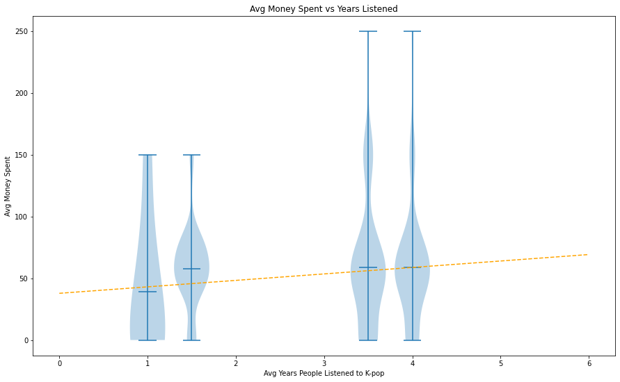

```python
#create violin plot comparing years listened (x axis) vs money spent (y axis)
years = np.sort(df.YEARS_LISTENED_INT.unique())
size = df.groupby(['YEARS_LISTENED_INT']).size().max()
years_listened_group = [[]*size for row in range(len(years))]

for row, col in df.iterrows():
    index, = np.where(years == col['YEARS_LISTENED_INT'])[0]
    years_listened_group[index].append(col['MONEY_SPENT_INT'])

fig, ax = plt.subplots(figsize=(15, 9))
ax.violinplot(years_listened_group , years, widths=0.4, showmeans=True)
ax.set_xlabel("Avg Years People Listened to K-pop")
ax.set_ylabel("Avg Money Spent")
ax.set_title("Avg Money Spent vs Years Listened")

#regression line
trend = np.polyfit(df['HOURS_LIS_INT'], df['MONEY_SPENT_INT'], 1)
print("Regression line slope: {} ".format(round(trend[0], 2)))
poly = np.poly1d(trend)
x = np.linspace(0, 6)
y = poly(x)
plt.plot(x, y, '--', color='orange')
plt.show()
```

```
Regression line slope: 5.2292
```

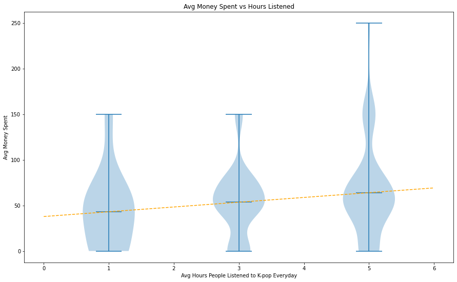

```python
#create violin plot comparing hours listened (x axis) vs money spent (y axis)
hours = np.sort(df.HOURS_LIS_INT.unique())
size = df.groupby(['HOURS_LIS_INT']).size().max()
hours_listened_group = [[]*size for row in range(len(hours))]

for row, col in df.iterrows():
    index, = np.where(hours == col['HOURS_LIS_INT'])[0]
    hours_listened_group[index].append(col['MONEY_SPENT_INT'])

fig, ax = plt.subplots(figsize=(15, 9))
ax.violinplot(hours_listened_group, hours, widths=0.8, showmeans=True)
ax.set_xlabel("Avg Hours People Listened to K-pop Everyday")
ax.set_ylabel("Avg Money Spent")
ax.set_title("Avg Money Spent vs Hours Listened")

#regression line
trend = np.polyfit(df['HOURS_LIS_INT'], df['MONEY_SPENT_INT'], 1)
print("Regression line slope: {} ".format(round(trend[0], 4)))
poly = np.poly1d(trend)
x = np.linspace(0, 6)
y = poly(x)
plt.plot(x, y, '--', color='orange')
plt.show()
```

Our next violin plot compared average hours people listened to k-pop daily vs average money spent on merchandise. The plot produced 3 violins for each type of response. The violin plot for 2 to 4 hours turned out to be least skewed and unimodal compared to less than 1 hour which was heavily skewed towards average money spent around 50 dollars. The money spent range for people who listen to 4 to 6 hours daily was largest due to outlier data points. We also plotted a linear regression line for all data points in the plot. According to the prediction, amount of average money spent increases \$5.2292 per hour.

```
Regression line slope: 4.3818
```

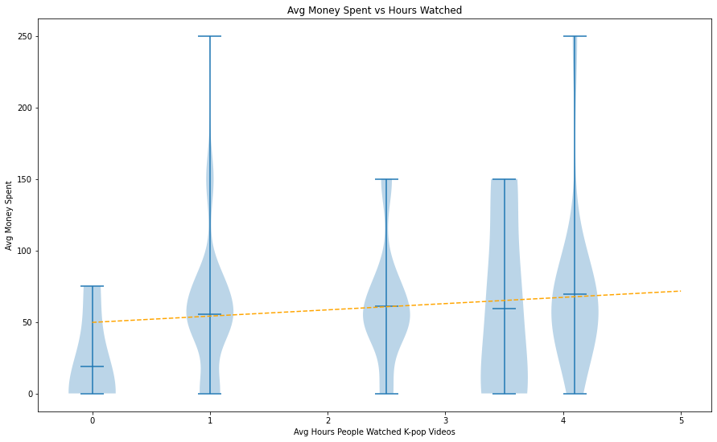

```python
#create violin plot comparing hours watched (x axis) vs money spent (y axis)
hours = np.sort(df.HOURS_WATCH_INT.unique())
size = df.groupby(['HOURS_WATCH_INT']).size().max()
hours_watched_group = [[]*size for row in range(len(hours))]

for row, col in df.iterrows():
    index, = np.where(hours == col['HOURS_WATCH_INT'])[0]
    hours_watched_group[index].append(col['MONEY_SPENT_INT'])

fig, ax = plt.subplots(figsize=(15, 9))
ax.violinplot(hours_watched_group, hours, widths=0.4, showmeans=True)
ax.set_xlabel("Avg Hours People Watched K-pop Videos")
ax.set_ylabel("Avg Money Spent")
ax.set_title("Avg Money Spent vs Hours Watched")

#regression line
trend = np.polyfit(df['HOURS_WATCH_INT'], df['MONEY_SPENT_INT'], 1)
print("Regression line slope: {} ".format(round(trend[0], 4)))
poly = np.poly1d(trend)
x = np.linspace(0, 5)
y = poly(x)
plt.plot(x, y, '--', color='orange')
plt.show()
```

# 4. Hypothesis testing

In this section, we decided to use LDA model to predict the amount of money people might spend on Kpop merchandise.

```python
#deal with the categorical parameters age, gender and attend_concert
model_df = df[['AGE', 'GENDER', 'MONEY_SPENT_INT', 'HOURS_LIS_INT', 'HOURS_WATCH_INT', 'PROFESSION', 'YEARS_LISTENED_INT']].copy(deep=True)
model_df = pd.get_dummies(model_df, columns=['AGE','GENDER', 'PROFESSION'])
target = model_df['MONEY_SPENT_INT'].copy(deep=True)
model_df.drop(['MONEY_SPENT_INT'], inplace=True, axis=1)

#create LDA model
X_train, X_test, y_train, y_test = train_test_split(model_df, target, test_size=0.4, random_state=0)
lda_model = LinearDiscriminantAnalysis()
lda_model = lda_model.fit(X_train, y_train)
lda_predict = lda_model.predict(X_test)
print("LDA performance metric")
print(classification_report(y_test, lda_predict, zero_division=0))
```

```
LDA performance metric
              precision    recall  f1-score   support

           0       0.64      0.93      0.76        56
          75       0.25      0.06      0.10        17
         150       0.00      0.00      0.00        12
        1000       0.00      0.00      0.00         1
        2000       0.00      0.00      0.00         1
        5000       0.00      0.00      0.00         0

    accuracy                           0.61        87
   macro avg       0.15      0.16      0.14        87
weighted avg       0.46      0.61      0.51        87
```

According to the LDA performance metric, it seems that the model didn't do quite well on predicting the amount of money people spent on K-pop merchandise. To improve our model performance, we consider additional parameters. These parameters are the values before we dropped the columns: "Would you say that you are obsessed with K-Pop?", "What is your profession?", and "Do you attend K-Pop concerts?", "'Is K-Pop popular in your country?".

```python
#deal with the categorical parameters obsession and profession
model_df = df[['AGE', 'GENDER', 'HOURS_LIS_INT', 'HOURS_WATCH_INT', 'OBSESSION', 'PROFESSION', 'NUM_SUSCRIBED',
               'ATTEND_CONCERT', 'POPULARITY']].copy(deep=True)
model_df = pd.get_dummies(model_df, columns=['AGE','GENDER', 'OBSESSION', 'PROFESSION', 'ATTEND_CONCERT', 'POPULARITY'])

#create LDA model
X_train, X_test, y_train, y_test = train_test_split(model_df, target, test_size=0.4, random_state=0)
lda_model = LinearDiscriminantAnalysis()
lda_model = lda_model.fit(X_train, y_train)
lda_predict = lda_model.predict(X_test)
print("LDA performance metric")
print(classification_report(y_test, lda_predict, zero_division=0))
```

```
LDA performance metric
              precision    recall  f1-score   support

           0       0.69      0.77      0.73        56
          75       0.14      0.18      0.16        17
         150       0.00      0.00      0.00        12
         250       0.00      0.00      0.00         0
        1000       0.00      0.00      0.00         1
        2000       0.00      0.00      0.00         1
        5000       0.00      0.00      0.00         0

    accuracy                           0.53        87
   macro avg       0.12      0.13      0.13        87
weighted avg       0.47      0.53      0.50        87
```

With more categorical values included, our LDA model performed slightly better, with precision 69% compared to 64% before adding more variables. On the other hand, our accuracy has dropped from 61% to 53%. Even though the entire performance doesn't improve that much, the model predicted relatively well on the class with value 0, the group which people don't spend money on merchandise at all.

# Conclusion and Communications and Insights Attained

The low accuracy and precision of the LDA model made us realize that the data was not consistent for the machine learning model. We speculate that the issue was due to not having enough data to correlate the different variables. Before cleaning, the dataset initially had 240 entries but after removing rows that were impossible to categorize, it was less than 220. In addition, even if we were trying to be as objective as possible when removing data, it is impossible to ignore the fact that our data selection was biased at the slightest. If we have performed the same tutorial for dataset size at least 1000 entries, we are certain that the LDA model would have given us better numbers.

That aside, we still predicted average money spent vs (average hours listened, average hours watched, and average years listened) using a linear regression model, which gave us positive slopes.

We hope that this tutorial will serve as a guidance for data scientists in the future who have obtained a better dataset for us. In addition, we are certain that this notebook can provide insight on how multiple factors of a k-pop fan can affect the money spent on k-pop merchandise for enhanced ad targeting that can lead to positive business and economic growth.

As k-pop continues its rise, we believe our analysis will aid the research of the reasons behind the rise of the k-pop industry and popularity.

Thank you.